# Exam 3 Skills Test

Kate Fox

April 8, 2026

# Load & Clean Faculty Salaries

In this section, I loaded the faculty salary dataset and transformed it into a tidy format. Tidying the data ensures that each row represents a single observation of salary by state, rank, and tier, making it easier to analyze and visualize.

```r
# Load dataset
salaries <- read.csv("FacultySalaries_1995.csv")
glimpse(salaries)
```

```
## Rows: 1,161
## Columns: 17
## $ FedID               <int> 1061, 1063, 1065, 11462, 1002, 1004, 1008, 1009, 1…
## $ UnivName            <chr> "Alaska Pacific University", "Univ.Alaska-Fairbank…
## $ State               <chr> "AK", "AK", "AK", "AK", "AL", "AL", "AL", "AL", "A…
## $ Tier                <chr> "IIB", "I", "IIA", "IIA", "IIA", "IIA", "IIB", "I"…
## $ AvgFullProfSalary   <int> 454, 686, 533, 612, 442, 441, 466, 580, 498, 506, …
## $ AvgAssocProfSalary  <int> 382, 560, 494, 507, 369, 385, 394, 437, 379, 412, …
## $ AvgAssistProfSalary <int> 362, 432, 329, 414, 310, 310, 351, 374, 322, 359, …
## $ AvgProfSalaryAll    <int> 382, 508, 415, 498, 350, 388, 396, 455, 401, 411, …
## $ AvgFullProfComp     <int> 567, 914, 716, 825, 530, 542, 558, 692, 655, 607, …
## $ AvgAssocProfComp    <int> 485, 753, 663, 681, 444, 473, 476, 527, 501, 508, …
## $ AvgAssistProfComp   <int> 471, 572, 442, 557, 376, 383, 427, 451, 404, 445, …
## $ AvgProfCompAll      <int> 487, 677, 559, 670, 423, 477, 478, 546, 523, 503, …
## $ NumFullProfs        <int> 6, 74, 9, 115, 59, 57, 20, 366, 34, 67, 8, 106, 27…
## $ NumAssocProfs       <int> 11, 125, 26, 124, 77, 33, 18, 354, 25, 40, 15, 42,…
## $ NumAssistProfs      <int> 9, 118, 20, 101, 102, 35, 30, 301, 27, 66, 19, 66,…
## $ NumInstructors      <int> 4, 40, 9, 21, 24, 2, 0, 66, 3, 27, 2, 58, 4, 19, 3…
## $ NumFacultyAll       <int> 32, 404, 70, 392, 262, 127, 68, 1109, 89, 200, 44,…
```

```r
# Clean the data set
salaries_tidy <- salaries %>%
  pivot_longer(
    cols = c(AvgFullProfSalary, AvgAssocProfSalary, AvgAssistProfSalary),
    names_to = "Rank",
    values_to = "Salary"
  ) %>%
  mutate(
    Rank = case_when(
      Rank == "AvgFullProfSalary" ~ "Full",
      Rank == "AvgAssocProfSalary" ~ "Associate",
      Rank == "AvgAssistProfSalary" ~ "Assistant"
    )
  )
```

To better understand salary distributions, I visualized salaries across faculty ranks and institutional tiers.

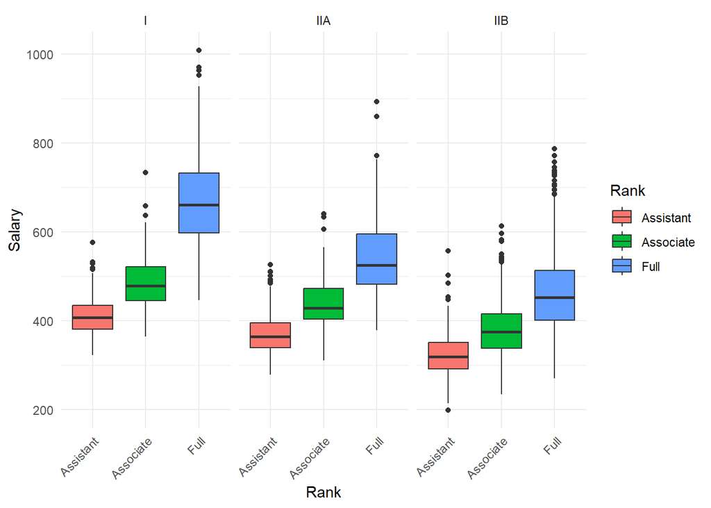

```r
salaries_tidy %>%
  filter(Tier %in% c("I", "IIA", "IIB")) %>%
  ggplot(aes(x = Rank, y = Salary, fill = Rank)) +
  geom_boxplot() +
  facet_wrap(~ Tier) +
  theme_minimal() +
  theme(axis.text.x = element_text(angle = 45, hjust = 1)) +
  labs(x = "Rank", y = "Salary")
```

# ANOVA Model

To evaluate whether State, Tier, and Rank have significant effects on salary, I fit an ANOVA model without interaction terms. This model allows us to assess the independent contribution of each factor.

```r
anova_model <- aov(Salary ~ State + Tier + Rank, data = salaries_tidy)
summary(anova_model)
```

```
##               Df   Sum Sq Mean Sq F value Pr(>F)
## State         51  5682396  111420   30.66 <2e-16 ***
## Tier           2  7072361 3536180  972.96 <2e-16 ***
## Rank           2 16529771 8264885 2274.04 <2e-16 ***
## Residuals   3299 11990072    3634
## ---
## Signif. codes:  0 '***' 0.001 '**' 0.01 '*' 0.05 '.' 0.1 ' ' 1
## 128 observations deleted due to missingness
```

The ANOVA output identifies which factors significantly influence salary variation across institutions.

# Load & Tidy Juniper Oils

Next, I loaded the Juniper Oils dataset and reshaped it into a tidy format. Each row now represents a single chemical concentration measurement for a given observation.

```r
# Load dataset
oils <- read_csv("Juniper_Oils.csv")

# List of chemical variables
chemicals <- c("alpha-pinene","para-cymene","alpha-terpineol","cedr-9-ene",
               "alpha-cedrene","beta-cedrene","cis-thujopsene","alpha-himachalene",
               "beta-chamigrene","cuparene","compound 1","alpha-chamigrene",
               "widdrol","cedrol","beta-acorenol","alpha-acorenol",
               "gamma-eudesmol","beta-eudesmol","alpha-eudesmol",
               "cedr-8-en-13-ol","cedr-8-en-15-ol","compound 2","thujopsenal")

# Tidy dataset
oils_tidy <- oils %>%
  pivot_longer(
    cols = all_of(chemicals),
    names_to = "ChemicalID",
    values_to = "Concentration"
  )
```

# Faceted Visualization

To explore how chemical concentrations vary with time since burn, I created faceted plots for each compound. This allows for easy comparison of trends across many chemicals.

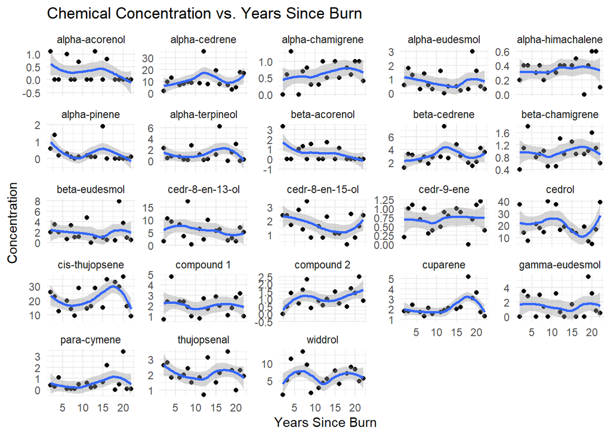

```r
ggplot(oils_tidy, aes(x = YearsSinceBurn, y = Concentration)) +
  geom_point() +
  geom_smooth(method = "loess", se = TRUE) +
  facet_wrap(~ChemicalID, scales = "free_y") +
  theme_minimal() +
  labs(
    title = "Chemical Concentration vs. Years Since Burn",
    x = "Years Since Burn",
    y = "Concentration"
  )
```

# Linear Model for Significant Chemicals

To determine which chemicals are significantly affected by time since burn, I fit a linear model including an interaction between chemical identity and time. This allows each chemical to have its own slope.

```r
glm_model <- lm(Concentration ~ ChemicalID * YearsSinceBurn, data = oils_tidy)

# Extract model results
results <- tidy(glm_model)

# Filter significant terms
significant_results <- results %>%
  filter(p.value < 0.05)

significant_results
```

```
## # A tibble: 6 × 5
##   term                                    estimate std.error statistic  p.value
##   <chr>                                      <dbl>     <dbl>     <dbl>    <dbl>
## 1 ChemicalIDalpha-cedrene                    7.88      1.93       4.08 4.97e- 5
## 2 ChemicalIDcedr-8-en-13-ol                  7.62      1.93       3.95 8.72e- 5
## 3 ChemicalIDcedrol                          22.5       1.93      11.7  5.12e-29
## 4 ChemicalIDcis-thujopsene                  17.3       1.93       8.95 2.93e-18
## 5 ChemicalIDwiddrol                          5.82      1.93       3.01 2.69e- 3
## 6 ChemicalIDcis-thujopsene:YearsSinceBurn    0.332     0.141      2.35 1.90e- 2
```

The significant interaction terms indicate which chemicals show meaningful changes in concentration over time since burn.